# Zoe Data Analysis

ZoeClarke

April 8, 2019

## Introduction

Interspecific interaction plays a large role in defining the composition of ecological communities. There are different reasons for this: specific niches, mutualism between species, resource competition, as well as other fixed and random effects. Relationships such as these can be the basis of complex communities that we can identify in nature.

Common garden experiments allow the fixation of certain factors that we otherwise cannot control in an observational study, and take measurements of the effects of controlled predictor variables. By analyzing multiple predictors, we can get a better idea of how significant certain species or ecological traits are in forming these communities. One such common garden is the Wisconsin Aspen (WisAsp) common garden.

The WisAsp common garden was established in 2010 at the University of Wisconsin’s Arlington Agricultural Research Station (43.32°N latitude, 89.33°W longitude). Different aspen (*Populus tremuloides*) tree genets (n=328) were gathered from all across Wisconsin (latitude range: 358 km, longitude range: 186 km), propogated from rootstock, and planted in the common garden with a randomized block design. The group running the experiment measured both tree traits and qualities of the insect communities that were found on each individual tree in both 2014 (n=979) and 2015 (n=986). The goal of the study was to determine potential relationships between the traits that they measured.

The study concluded that: insect communities were impacted mostly by relationships among major groups of insects (ie. aphids, ants, and free-feeders); these insect communities were also impacted by tree traits, especially tree size and foliar phenology; and timing of bud break and bud set influenced particular insect species and groups. In our project, we aim to test these findings, as well as explore different relationships that may potentially be found in this common garden.

## Methods and Results

### Analysis of the timing of bud break and bud set on insepct species and functional groups.

Barker et al. mentioned that the timing of bud set and especially of bud set impacted the species of insects that were present on the trees in 2014 and 2015. This may be because different types of insects thrive at different points in the growing season and therefore must rely on the trees that bud at an agreeable time for the particular insect.

I will test these results by making trees of distances matrices quantifying the differences between insect communities.

```r
# Load necessary libraries
library(dplyr)
```

```r
library(ggplot2)
library(ggtree)
library(cowplot)
# Load the data
dat2014 <- read.csv("buggy-aspens/WisAsp_2014-5_DryadData_2014.csv")
dat2015 <- read.csv("buggy-aspens/WisAsp_2014-5_DryadData_2015.csv")
```

#### 2014 data:

```r
summary(dat2014) # Take a look at the 2014 data
```

```
##      ï..BLK           ROW           POS             GENO
##  Min.   :1.000   D      : 78   Min.   : 1.00   Min.   :  1.0
##  1st Qu.:1.000   B      : 77   1st Qu.: 7.00   1st Qu.:111.8
##  Median :2.000   E      : 76   Median :15.00   Median :204.0
##  Mean   :2.387   C      : 73   Mean   :14.65   Mean   :201.7
##  3rd Qu.:3.000   A      : 71   3rd Qu.:22.00   3rd Qu.:297.0
##  Max.   :4.000   F      : 71   Max.   :28.00   Max.   :392.0
##                  (Other):533                   NA's   :1
##        ID        Total.Time       FreeFeeder       LeafModifier
##  1 A 1  :  1   Min.   : 3.000   Min.   :  0.000   Min.   : 0.000
##  1 A 12 :  1   1st Qu.: 6.000   1st Qu.:  0.167   1st Qu.: 0.500
##  1 A 13 :  1   Median : 9.000   Median :  1.000   Median : 0.889
##  1 A 14 :  1   Mean   : 8.599   Mean   :  4.930   Mean   : 1.176
##  1 A 15 :  1   3rd Qu.:12.000   3rd Qu.:  4.333   3rd Qu.: 1.417
##  1 A 16 :  1   Max.   :24.000   Max.   :283.000   Max.   :16.000
##  (Other):973
##   WoodModifier            Ant         Cecidomyiidae     Tenthredinidae
##  Min.   :0.0000000   Min.   :0.0000   Min.   :0.00000   Min.   :0.0000
##  1st Qu.:0.0000000   1st Qu.:0.0000   1st Qu.:0.00000   1st Qu.:0.0000
##  Median :0.0000000   Median :0.0000   Median :0.00000   Median :0.1670
##  Mean   :0.0007007   Mean   :0.1675   Mean   :0.07981   Mean   :0.2985
##  3rd Qu.:0.0000000   3rd Qu.:0.0000   3rd Qu.:0.00000   3rd Qu.:0.3330
##  Max.   :0.2220000   Max.   :9.3330   Max.   :3.77800   Max.   :4.0000
##
##   Nepticulidae    Gracilliaridae    Agromyzidae       Notodontidae
##  Min.   :0.0000   Min.   :0.0000   Min.   :0.00000   Min.   : 0.0000
##  1st Qu.:0.0000   1st Qu.:0.0830   1st Qu.:0.00000   1st Qu.: 0.0000
##  Median :0.1110   Median :0.2500   Median :0.00000   Median : 0.0830
##  Mean   :0.2603   Mean   :0.3372   Mean   :0.06491   Mean   : 0.2154
##  3rd Qu.:0.3330   3rd Qu.:0.5000   3rd Qu.:0.08300   3rd Qu.: 0.1835
##  Max.   :8.9170   Max.   :2.6670   Max.   :1.66700   Max.   :12.5000
##
##   Tortricidae        Aphididae         Formicidae     Chrysomelidae
##  Min.   :0.00000   Min.   :  0.000   Min.   :0.0000   Min.   :0.00000
##  1st Qu.:0.00000   1st Qu.:  0.000   1st Qu.:0.0000   1st Qu.:0.00000
##  Median :0.00000   Median :  0.667   Median :0.0000   Median :0.00000
##  Mean   :0.01626   Mean   :  4.728   Mean   :0.1675   Mean   :0.01311
##  3rd Qu.:0.00000   3rd Qu.:  4.097   3rd Qu.:0.0000   3rd Qu.:0.00000
##  Max.   :0.66700   Max.   :282.667   Max.   :9.3330   Max.   :0.33300
##
```

[output cut: 65 more lines]

```
##  Min.   : 82.60   Min.   : 2.820   Min.   :0.462   Min.   :0.130
##  1st Qu.: 99.53   1st Qu.: 9.848   1st Qu.:2.412   1st Qu.:1.890
##  Median :108.22   Median :12.850   Median :3.270   Median :2.965
##  Mean   :108.57   Mean   :12.921   Mean   :3.334   Mean   :3.240
##  3rd Qu.:116.72   3rd Qu.:15.707   3rd Qu.:4.228   3rd Qu.:4.340
##  Max.   :133.28   Max.   :28.680   Max.   :8.221   Max.   :9.770
##  NA's   :24       NA's   :11       NA's   :18      NA's   :13
##      CN2014           N2014
##  Min.   : 0.702   Min.   :11.01
##  1st Qu.: 4.309   1st Qu.:18.10
##  Median : 6.222   Median :20.61
##  Mean   : 6.570   Mean   :21.11
##  3rd Qu.: 8.589   3rd Qu.:23.66
##  Max.   :17.991   Max.   :37.64
##  NA's   :19       NA's   :26
```

```r
# Rename the first column because it includes a unique character
dat2014 <- rename(dat2014, BLK = ï..BLK)
# Select only bud and insect data
dat2014 <- select(dat2014, ID, FreeFeeder:Lasius_neoniger, BB2014, BS2014)
names(dat2014)# Check to make sure I have the right columns
```

```
##  [1] "ID"                      "FreeFeeder"
##  [3] "LeafModifier"            "WoodModifier"
##  [5] "Ant"                     "Cecidomyiidae"
##  [7] "Tenthredinidae"          "Nepticulidae"
##  [9] "Gracilliaridae"          "Agromyzidae"
## [11] "Notodontidae"            "Tortricidae"
## [13] "Aphididae"               "Formicidae"
## [15] "Chrysomelidae"           "Pentatomidae"
## [17] "Membracidae"             "Harmandia"
## [19] "Phyllocolpa"             "PetioleGall"
## [21] "LeafEdgeMine"            "SerpMine"
## [23] "BlotchMine"              "LombardyMine"
## [25] "Gluphisia"               "GreenNematus"
## [27] "RustylinedLeaftier"      "ObliqueBandedLeafRoller"
## [29] "SmokeyAphids"            "GreenAphids"
## [31] "Lasius_neoniger"         "BB2014"
## [33] "BS2014"
```

```r
# Get rid of spaces in ID using regular expressions
dat2014$ID <- gsub("\\s", "", dat2014$ID)
summary(dat2014) # Check the data
```

```
##       ID              FreeFeeder       LeafModifier     WoodModifier
##  Length:979         Min.   :  0.000   Min.   : 0.000   Min.   :0.0000000
##  Class :character   1st Qu.:  0.167   1st Qu.: 0.500   1st Qu.:0.0000000
##  Mode  :character   Median :  1.000   Median : 0.889   Median :0.0000000
##                     Mean   :  4.930   Mean   : 1.176   Mean   :0.0007007
##                     3rd Qu.:  4.333   3rd Qu.: 1.417   3rd Qu.:0.0000000
##                     Max.   :283.000   Max.   :16.000   Max.   :0.2220000
##
##       Ant         Cecidomyiidae     Tenthredinidae    Nepticulidae
##  Min.   :0.0000   Min.   :0.00000   Min.   :0.0000   Min.   :0.0000
##  1st Qu.:0.0000   1st Qu.:0.00000   1st Qu.:0.0000   1st Qu.:0.0000
##  Median :0.0000   Median :0.00000   Median :0.1670   Median :0.1110
##  Mean   :0.1675   Mean   :0.07981   Mean   :0.2985   Mean   :0.2603
##  3rd Qu.:0.0000   3rd Qu.:0.00000   3rd Qu.:0.3330   3rd Qu.:0.3330
##  Max.   :9.3330   Max.   :3.77800   Max.   :4.0000   Max.   :8.9170
##
##  Gracilliaridae    Agromyzidae       Notodontidae      Tortricidae
##  Min.   :0.0000   Min.   :0.00000   Min.   : 0.0000   Min.   :0.00000
##  1st Qu.:0.0830   1st Qu.:0.00000   1st Qu.: 0.0000   1st Qu.:0.00000
##  Median :0.2500   Median :0.00000   Median : 0.0830   Median :0.00000
##  Mean   :0.3372   Mean   :0.06491   Mean   : 0.2154   Mean   :0.01626
##  3rd Qu.:0.5000   3rd Qu.:0.08300   3rd Qu.: 0.1835   3rd Qu.:0.00000
##  Max.   :2.6670   Max.   :1.66700   Max.   :12.5000   Max.   :0.66700
##
##    Aphididae         Formicidae     Chrysomelidae      Pentatomidae
##  Min.   :  0.000   Min.   :0.0000   Min.   :0.00000   Min.   : 0.00000
##  1st Qu.:  0.000   1st Qu.:0.0000   1st Qu.:0.00000   1st Qu.: 0.00000
##  Median :  0.667   Median :0.0000   Median :0.00000   Median : 0.00000
##  Mean   :  4.728   Mean   :0.1675   Mean   :0.01311   Mean   : 0.06304
##  3rd Qu.:  4.097   3rd Qu.:0.0000   3rd Qu.:0.00000   3rd Qu.: 0.00000
##  Max.   :282.667   Max.   :9.3330   Max.   :0.33300   Max.   :20.00000
##
##   Membracidae        Harmandia        Phyllocolpa      PetioleGall
##  Min.   :0.00000   Min.   :0.00000   Min.   :0.0000   Min.   :0.0000
##  1st Qu.:0.00000   1st Qu.:0.00000   1st Qu.:0.0000   1st Qu.:0.0000
##  Median :0.00000   Median :0.00000   Median :0.1670   Median :0.1110
##  Mean   :0.00921   Mean   :0.07755   Mean   :0.2892   Mean   :0.2607
##  3rd Qu.:0.00000   3rd Qu.:0.00000   3rd Qu.:0.3330   3rd Qu.:0.3330
##  Max.   :0.33300   Max.   :3.77800   Max.   :4.0000   Max.   :8.9170
##                    NA's   :4         NA's   :4        NA's   :4
```

[output cut: 17 more lines]

```
##  Min.   :0.00000         Min.   :  0.000   Min.   :  0.000
##  1st Qu.:0.00000         1st Qu.:  0.000   1st Qu.:  0.000
##  Median :0.00000         Median :  0.000   Median :  0.000
##  Mean   :0.01579         Mean   :  2.737   Mean   :  2.004
##  3rd Qu.:0.00000         3rd Qu.:  0.903   3rd Qu.:  1.544
##  Max.   :0.66700         Max.   :282.667   Max.   :208.667
##  NA's   :4               NA's   :4         NA's   :4
##  Lasius_neoniger       BB2014           BS2014
##  Min.   :0.00000   Min.   : 5.570   Min.   : 5.78
##  1st Qu.:0.00000   1st Qu.: 9.475   1st Qu.:11.59
##  Median :0.00000   Median :11.090   Median :13.16
##  Mean   :0.05893   Mean   :11.419   Mean   :13.42
##  3rd Qu.:0.00000   3rd Qu.:12.895   3rd Qu.:14.97
##  Max.   :4.00000   Max.   :25.560   Max.   :21.33
##  NA's   :4         NA's   :8        NA's   :11
```

Set up the data so that distance for species can be calculated

```r
species2014 <- (dat2014[,c(18:31)]) # Isolate species data
rownames(species2014) <- dat2014$ID # Assign rownames as ID
species2014 <- tidyr::drop_na(species2014) # Drop missing values
speciesDist2014 <- vegan::vegdist(species2014) # Calculate distance and make a tree
speciesTree2014 <- ape::nj(speciesDist2014) # Make tree of distance matrix
# Plot the tree for bud set
speciesTreeSet2014 <- ggtree(speciesTree2014, layout = "rectangular") %<+% dat2014 +
  geom_tippoint(aes(colour = BS2014), size = I(3), shape = I(18)) +
  scale_colour_gradientn(colours = rainbow(10), na.value = "grey50",
                         name = "Julian date") +
  theme(legend.position = "right")
# Plot tree for bud break
speciesTreeBreak2014 <- ggtree(speciesTree2014, layout = "rectangular") %<+% dat2014 +
  geom_tippoint(aes(colour = BB2014), size = I(3), shape = I(18)) +
  scale_colour_gradientn(colours = rainbow(10), na.value = "grey50",
                         name = "Julian date") +
  theme(legend.position = "right")
```

Now look at functional groups

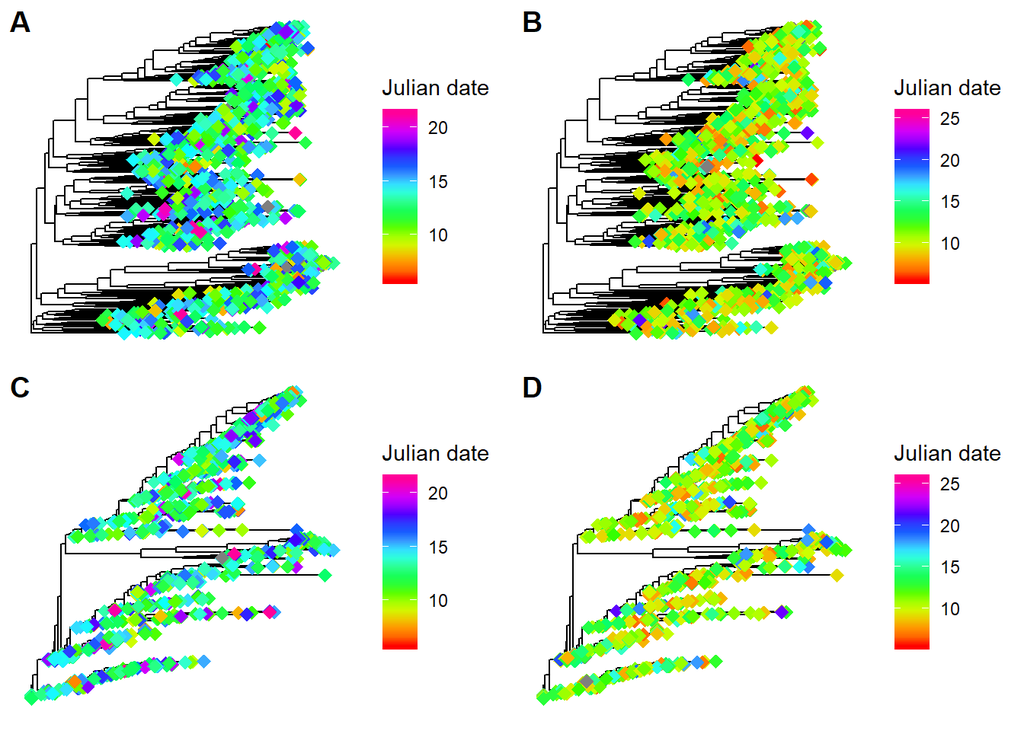

```r
groups2014 <- (dat2014[,c(2:5)]) # Isolate functional group data
rownames(groups2014) <- dat2014$ID # Assign rownames as ID
groupsDist2014 <- vegan::vegdist(groups2014) # Calculate distance
groupsTree2014 <- ape::nj(groupsDist2014) # Make tree of distance matrix
# Plot the tree for bud set
groupsTreeSet2014 <- ggtree(groupsTree2014, layout = "rectangular") %<+% dat2014 +
  geom_tippoint(aes(colour = BS2014), size = I(3), shape = I(18)) +
  scale_colour_gradientn(colours = rainbow(10), na.value = "grey50",
                         name = "Julian date") +
  theme(legend.position = "right")
# Plot the tree for bud break
groupsTreeBreak2014 <- ggtree(groupsTree2014, layout = "rectangular") %<+% dat2014 +
  geom_tippoint(aes(colour = BB2014), size = I(3), shape = I(18)) +
  scale_colour_gradientn(colours = rainbow(10), na.value = "grey50",
                         name = "Julian date") +
  theme(legend.position = "right")
# Plot together on grid
plot_grid(speciesTreeSet2014, speciesTreeBreak2014, groupsTreeSet2014,
             groupsTreeBreak2014, ncol = 2, labels = "AUTO")
```

#### 2015 data:

```r
summary(dat2015) # Take a look at the 2015 data
```

```
##      ï..BLK           ROW           POS             GENO
##  Min.   :1.000   D      : 78   Min.   : 1.00   Min.   :  1.0
##  1st Qu.:1.000   B      : 77   1st Qu.: 7.00   1st Qu.:111.0
##  Median :2.000   E      : 77   Median :15.00   Median :205.0
##  Mean   :2.387   A      : 74   Mean   :14.59   Mean   :201.8
##  3rd Qu.:3.000   C      : 73   3rd Qu.:22.00   3rd Qu.:297.0
##  Max.   :4.000   F      : 73   Max.   :28.00   Max.   :392.0
##                  (Other):534                   NA's   :1
##        ID        Total.time       FreeFeeder       LeafModifier
##  1 A 1  :  1   Min.   : 1.000   Min.   :  0.000   Min.   : 0.167
##  1 A 11 :  1   1st Qu.: 6.000   1st Qu.:  0.111   1st Qu.: 1.556
##  1 A 12 :  1   Median : 6.000   Median :  1.444   Median : 2.472
##  1 A 13 :  1   Mean   : 7.315   Mean   :  8.222   Mean   : 2.746
##  1 A 14 :  1   3rd Qu.: 9.000   3rd Qu.:  5.333   3rd Qu.: 3.444
##  1 A 15 :  1   Max.   :33.000   Max.   :967.833   Max.   :12.167
##  (Other):980
##   WoodModifier           Ant          Cecidomyiidae    Tenthredinidae
##  Min.   :0.000000   Min.   : 0.0000   Min.   :0.0000   Min.   :0.0000
##  1st Qu.:0.000000   1st Qu.: 0.0000   1st Qu.:0.0000   1st Qu.:0.2220
##  Median :0.000000   Median : 0.0000   Median :0.1330   Median :0.6670
##  Mean   :0.001627   Mean   : 0.3825   Mean   :0.3480   Mean   :0.8392
##  3rd Qu.:0.000000   3rd Qu.: 0.4170   3rd Qu.:0.3832   3rd Qu.:1.1670
##  Max.   :0.222000   Max.   :11.3330   Max.   :5.3330   Max.   :8.6670
##
##   Nepticulidae     Graciliaridae    Lyonetiidae       Agromyzidae
##  Min.   : 0.0000   Min.   :0.000   Min.   :0.00000   Min.   :0.0000
##  1st Qu.: 0.0000   1st Qu.:0.222   1st Qu.:0.00000   1st Qu.:0.0000
##  Median : 0.2220   Median :0.444   Median :0.00000   Median :0.2220
##  Mean   : 0.5597   Mean   :0.623   Mean   :0.01251   Mean   :0.2772
##  3rd Qu.: 0.6670   3rd Qu.:0.833   3rd Qu.:0.00000   3rd Qu.:0.4170
##  Max.   :10.0000   Max.   :4.500   Max.   :1.00000   Max.   :2.3330
##
##  Megalopodidae      Notodontidae       Noctuidae        Tortricidae
##  Min.   :0.00000   Min.   :0.00000   Min.   :0.00000   Min.   :0.00000
##  1st Qu.:0.00000   1st Qu.:0.00000   1st Qu.:0.00000   1st Qu.:0.00000
##  Median :0.00000   Median :0.00000   Median :0.00000   Median :0.00000
##  Mean   :0.03008   Mean   :0.01843   Mean   :0.01191   Mean   :0.06152
##  3rd Qu.:0.00000   3rd Qu.:0.00000   3rd Qu.:0.00000   3rd Qu.:0.11100
##  Max.   :1.00000   Max.   :0.66700   Max.   :0.33300   Max.   :1.00000
##
```

[output cut: 73 more lines]

```
##  Min.   : 2.27   Min.   :0.429   Min.   : 0.200   Min.   : 0.769
##  1st Qu.:11.25   1st Qu.:2.606   1st Qu.: 2.380   1st Qu.: 5.072
##  Median :14.70   Median :3.527   Median : 3.710   Median : 7.346
##  Mean   :14.80   Mean   :3.575   Mean   : 3.994   Mean   : 7.570
##  3rd Qu.:17.87   3rd Qu.:4.536   3rd Qu.: 5.470   3rd Qu.:10.075
##  Max.   :35.99   Max.   :7.672   Max.   :10.840   Max.   :16.317
##  NA's   :5       NA's   :14      NA's   :13       NA's   :14
##      CN2015          N2015
##  Min.   :12.82   Min.   :17.69
##  1st Qu.:21.06   1st Qu.:22.43
##  Median :23.65   Median :24.04
##  Mean   :24.10   Mean   :24.08
##  3rd Qu.:26.94   3rd Qu.:25.66
##  Max.   :41.33   Max.   :31.11
##  NA's   :17      NA's   :6
```

```r
# Rename the first column because it includes a unique character
dat2015 <- rename(dat2015, BLK = ï..BLK)
# Select only bud and insect data
dat2015 <- select(dat2015, ID, FreeFeeder:Lasius_alienus, BB2015, BS2015)
names(dat2015) # Check to make sure I have the right columns
```

```
##  [1] "ID"                      "FreeFeeder"
##  [3] "LeafModifier"            "WoodModifier"
##  [5] "Ant"                     "Cecidomyiidae"
##  [7] "Tenthredinidae"          "Nepticulidae"
##  [9] "Graciliaridae"           "Lyonetiidae"
## [11] "Agromyzidae"             "Megalopodidae"
## [13] "Notodontidae"            "Noctuidae"
## [15] "Tortricidae"             "Aphididae"
## [17] "Formicidae"              "Chrysomelidae"
## [19] "Delphacidae"             "Pentatomidae"
## [21] "Harmandia"               "Phyllocolpa"
## [23] "PetioleGall"             "LeafEdgeMine"
## [25] "SerpMine"                "CottonwoodMine"
## [27] "BlotchMine"              "LombardyMine"
## [29] "BlackMine"               "LeafCurlMidge"
## [31] "CottonwoodDagger"        "RustylinedLeaftier"
## [33] "ObliqueBandedLeafRoller" "GreenAphids"
## [35] "SmokeyAphids"            "Formica_glacialis"
## [37] "Lasius_neoniger"         "Lasius_alienus"
## [39] "BB2015"                  "BS2015"
```

```r
# Get rid of spaces in ID using regular expressions
dat2015$ID <- gsub("\\s", "", dat2015$ID)
summary(dat2015) # Check the data
```

```
##       ID              FreeFeeder       LeafModifier     WoodModifier
##  Length:986         Min.   :  0.000   Min.   : 0.167   Min.   :0.000000
##  Class :character   1st Qu.:  0.111   1st Qu.: 1.556   1st Qu.:0.000000
##  Mode  :character   Median :  1.444   Median : 2.472   Median :0.000000
##                     Mean   :  8.222   Mean   : 2.746   Mean   :0.001627
##                     3rd Qu.:  5.333   3rd Qu.: 3.444   3rd Qu.:0.000000
##                     Max.   :967.833   Max.   :12.167   Max.   :0.222000
##
##       Ant          Cecidomyiidae    Tenthredinidae    Nepticulidae
##  Min.   : 0.0000   Min.   :0.0000   Min.   :0.0000   Min.   : 0.0000
##  1st Qu.: 0.0000   1st Qu.:0.0000   1st Qu.:0.2220   1st Qu.: 0.0000
##  Median : 0.0000   Median :0.1330   Median :0.6670   Median : 0.2220
##  Mean   : 0.3825   Mean   :0.3480   Mean   :0.8392   Mean   : 0.5597
##  3rd Qu.: 0.4170   3rd Qu.:0.3832   3rd Qu.:1.1670   3rd Qu.: 0.6670
##  Max.   :11.3330   Max.   :5.3330   Max.   :8.6670   Max.   :10.0000
##
##  Graciliaridae    Lyonetiidae       Agromyzidae     Megalopodidae
##  Min.   :0.000   Min.   :0.00000   Min.   :0.0000   Min.   :0.00000
##  1st Qu.:0.222   1st Qu.:0.00000   1st Qu.:0.0000   1st Qu.:0.00000
##  Median :0.444   Median :0.00000   Median :0.2220   Median :0.00000
##  Mean   :0.623   Mean   :0.01251   Mean   :0.2772   Mean   :0.03008
##  3rd Qu.:0.833   3rd Qu.:0.00000   3rd Qu.:0.4170   3rd Qu.:0.00000
##  Max.   :4.500   Max.   :1.00000   Max.   :2.3330   Max.   :1.00000
##
##   Notodontidae       Noctuidae        Tortricidae        Aphididae
##  Min.   :0.00000   Min.   :0.00000   Min.   :0.00000   Min.   :  0.000
##  1st Qu.:0.00000   1st Qu.:0.00000   1st Qu.:0.00000   1st Qu.:  0.000
##  Median :0.00000   Median :0.00000   Median :0.00000   Median :  1.111
##  Mean   :0.01843   Mean   :0.01191   Mean   :0.06152   Mean   :  8.042
##  3rd Qu.:0.00000   3rd Qu.:0.00000   3rd Qu.:0.11100   3rd Qu.:  5.104
##  Max.   :0.66700   Max.   :0.33300   Max.   :1.00000   Max.   :967.833
##
##    Formicidae      Chrysomelidae     Delphacidae        Pentatomidae
##  Min.   : 0.0000   Min.   :0.0000   Min.   :0.000000   Min.   :0.00000
##  1st Qu.: 0.0000   1st Qu.:0.0000   1st Qu.:0.000000   1st Qu.:0.00000
##  Median : 0.0000   Median :0.0000   Median :0.000000   Median :0.00000
##  Mean   : 0.3813   Mean   :0.0113   Mean   :0.007693   Mean   :0.06492
##  3rd Qu.: 0.4170   3rd Qu.:0.0000   3rd Qu.:0.000000   3rd Qu.:0.00000
##  Max.   :11.3330   Max.   :0.8890   Max.   :0.333000   Max.   :4.66700
##
```

[output cut: 33 more lines]

```
##  Min.   : 0.00000   Min.   :0.0000   Min.   :0.00000   Min.   : 48.56
##  1st Qu.: 0.00000   1st Qu.:0.0000   1st Qu.:0.00000   1st Qu.:128.19
##  Median : 0.00000   Median :0.0000   Median :0.00000   Median :136.62
##  Mean   : 0.08597   Mean   :0.1543   Mean   :0.06855   Mean   :137.18
##  3rd Qu.: 0.00000   3rd Qu.:0.0000   3rd Qu.:0.00000   3rd Qu.:145.74
##  Max.   :10.00000   Max.   :5.3330   Max.   :4.11100   Max.   :188.31
##                                                        NA's   :15
##      BS2015
##  Min.   :125.8
##  1st Qu.:128.6
##  Median :130.0
##  Mean   :130.9
##  3rd Qu.:132.3
##  Max.   :147.6
##  NA's   :6
```

Set up data so that species distance can be calculated

```r
species2015 <- (dat2015[,c(21:38)]) # Isolate species data
rownames(species2015) <- dat2015$ID # Assign rownames as ID
speciesDist2015 <- vegan::vegdist(species2015) # Calculate distance and make a tree
speciesTree2015 <- ape::nj(speciesDist2015) # Make tree of distance matrix
# Plot bud set tree
speciesTreeSet2015 <- ggtree(speciesTree2015, layout = "rectangular") %<+% dat2015 +
  geom_tippoint(aes(colour = BS2015), size = I(3), shape = I(18)) +
  scale_colour_gradientn(colours = rainbow(10), na.value = "grey50",
                         name = "Julian date") +
  theme(legend.position = "right")
# Plot bud break tree
speciesTreeBreak2015 <- ggtree(speciesTree2015, layout = "rectangular") %<+% dat2015 +
  geom_tippoint(aes(colour = BB2015), size = I(3), shape = I(18)) +
  scale_colour_gradientn(colours = rainbow(10), na.value = "grey50",
                         name = "Julian date") +
  theme(legend.position = "right")
```

Now look at functional groups

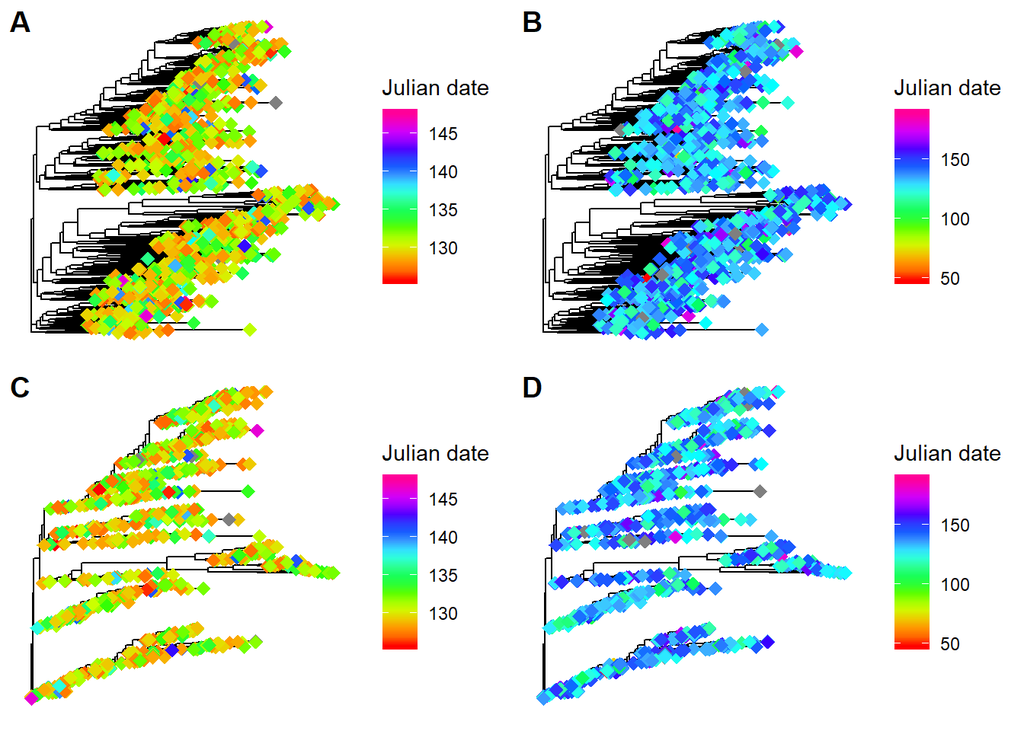

```r
groups2015 <- (dat2015[,c(2:5)]) # Isolate functional group data
rownames(groups2015) <- dat2015$ID # Assign rownames as ID
groupsDist2015 <- vegan::vegdist(groups2015) # Calculate distance
groupsTree2015 <- ape::nj(groupsDist2015) # Make tree of distance matrix
# Plot the tree for bud set
groupsTreeSet2015 <- ggtree(groupsTree2015, layout = "rectangular") %<+% dat2015 +
  geom_tippoint(aes(colour = BS2015), size = I(3), shape = I(18)) +
  scale_colour_gradientn(colours = rainbow(10), na.value = "grey50",
                         name = "Julian date") +
  theme(legend.position = "right")
# Plot the tree for bud break
groupsTreeBreak2015 <- ggtree(groupsTree2015, layout = "rectangular") %<+% dat2015 +
  geom_tippoint(aes(colour = BB2015), size = I(3), shape = I(18)) +
  scale_colour_gradientn(colours = rainbow(10), na.value = "grey50",
                         name = "Julian date") +
  theme(legend.position = "right")
# Plot together on a grid
plot_grid(speciesTreeSet2015, speciesTreeBreak2015, groupsTreeSet2015,
             groupsTreeBreak2015, ncol = 2, labels = "AUTO")
```

## Interpretation of results and discussion

Because the Barker et al. (2018) paper found that the timing of bud set and bud break impacted the species composition of communities, I decided to see if insect communities with a similar species or group composition would be found on trees with similar bud set and bud break dates. However, after building trees from distance matrices for both 2014 (Figure 1) and 2015 (Figure 2) data, I found no clustering of dates for neither similar insect species (Figure 1 and 2, A and B) nor similar insect group (Figure 1 and 2, C and D) composition. This suggests that perhaps the paper’s findings are much more species specific and require a closer look at trends within each species on the different trees to be able to distinguish changes between the communities.